## Chapter 3: Logistic Regression

```r
date()
```

```
## [1] "Tue Nov 23 15:43:10 2021"
```

Here we go again…

Remember! Set your working directory and load your libraries.

```r
knitr::opts_knit$set(root.dir ="C:/Users/ramosgon/OneDrive - University of Helsinki/Courses/OpenDataScience/IODS-project/Data")

library(tidyverse)
library(ggplot2)
library(MASS)
library(corrplot)
library(GGally)
library(car)
```

We read the data.

```r
data("Boston")
```

“Housing Values in Suburbs of Boston” is a data set native to the MASS package in R. The data set includes various indicators for the different Boston suburbs. Further explanation on the variables can be found [here](https://stat.ethz.ch/R-manual/R-devel/library/MASS/html/Boston.html).

We first explore the dimensions and structure.

```r
dim(Boston)
```

```
## [1] 506  14
```

```r
str(Boston)
```

```
## 'data.frame':    506 obs. of  14 variables:
##  $ crim   : num  0.00632 0.02731 0.02729 0.03237 0.06905 ...
##  $ zn     : num  18 0 0 0 0 0 12.5 12.5 12.5 12.5 ...
##  $ indus  : num  2.31 7.07 7.07 2.18 2.18 2.18 7.87 7.87 7.87 7.87 ...
##  $ chas   : int  0 0 0 0 0 0 0 0 0 0 ...
##  $ nox    : num  0.538 0.469 0.469 0.458 0.458 0.458 0.524 0.524 0.524 0.524 ...
##  $ rm     : num  6.58 6.42 7.18 7 7.15 ...
##  $ age    : num  65.2 78.9 61.1 45.8 54.2 58.7 66.6 96.1 100 85.9 ...
##  $ dis    : num  4.09 4.97 4.97 6.06 6.06 ...
##  $ rad    : int  1 2 2 3 3 3 5 5 5 5 ...
##  $ tax    : num  296 242 242 222 222 222 311 311 311 311 ...
##  $ ptratio: num  15.3 17.8 17.8 18.7 18.7 18.7 15.2 15.2 15.2 15.2 ...
##  $ black  : num  397 397 393 395 397 ...
##  $ lstat  : num  4.98 9.14 4.03 2.94 5.33 ...
##  $ medv   : num  24 21.6 34.7 33.4 36.2 28.7 22.9 27.1 16.5 18.9 ...
```

The data set contains mostly numeric variables with the exception of **rad** (index of accessibility to radial highways) and **chas** (Charles River dummy variable (= 1 if tract bounds river; 0 otherwise)). They are a ranked factor and a logical variable respectively. Therefore we convert them and look at the results.

**Note:** Because of rad increased number of factor levels, we will keep as integer.

```r
Boston <- Boston %>%
  mutate(chas = as.logical(chas))

summary(Boston)
```

```
##       crim                zn             indus          chas
##  Min.   : 0.00632   Min.   :  0.00   Min.   : 0.46   Mode :logical
##  1st Qu.: 0.08205   1st Qu.:  0.00   1st Qu.: 5.19   FALSE:471
##  Median : 0.25651   Median :  0.00   Median : 9.69   TRUE :35
##  Mean   : 3.61352   Mean   : 11.36   Mean   :11.14
##  3rd Qu.: 3.67708   3rd Qu.: 12.50   3rd Qu.:18.10
##  Max.   :88.97620   Max.   :100.00   Max.   :27.74
##       nox               rm             age              dis
##  Min.   :0.3850   Min.   :3.561   Min.   :  2.90   Min.   : 1.130
##  1st Qu.:0.4490   1st Qu.:5.886   1st Qu.: 45.02   1st Qu.: 2.100
##  Median :0.5380   Median :6.208   Median : 77.50   Median : 3.207
##  Mean   :0.5547   Mean   :6.285   Mean   : 68.57   Mean   : 3.795
##  3rd Qu.:0.6240   3rd Qu.:6.623   3rd Qu.: 94.08   3rd Qu.: 5.188
##  Max.   :0.8710   Max.   :8.780   Max.   :100.00   Max.   :12.127
##       rad              tax           ptratio          black
##  Min.   : 1.000   Min.   :187.0   Min.   :12.60   Min.   :  0.32
##  1st Qu.: 4.000   1st Qu.:279.0   1st Qu.:17.40   1st Qu.:375.38
##  Median : 5.000   Median :330.0   Median :19.05   Median :391.44
##  Mean   : 9.549   Mean   :408.2   Mean   :18.46   Mean   :356.67
##  3rd Qu.:24.000   3rd Qu.:666.0   3rd Qu.:20.20   3rd Qu.:396.23
##  Max.   :24.000   Max.   :711.0   Max.   :22.00   Max.   :396.90
##      lstat            medv
##  Min.   : 1.73   Min.   : 5.00
##  1st Qu.: 6.95   1st Qu.:17.02
##  Median :11.36   Median :21.20
##  Mean   :12.65   Mean   :22.53
##  3rd Qu.:16.95   3rd Qu.:25.00
##  Max.   :37.97   Max.   :50.00
```

The past table provides a lot on information on quartile distribution of our variables, but I always rather look at the variables with boxplots or barplots:

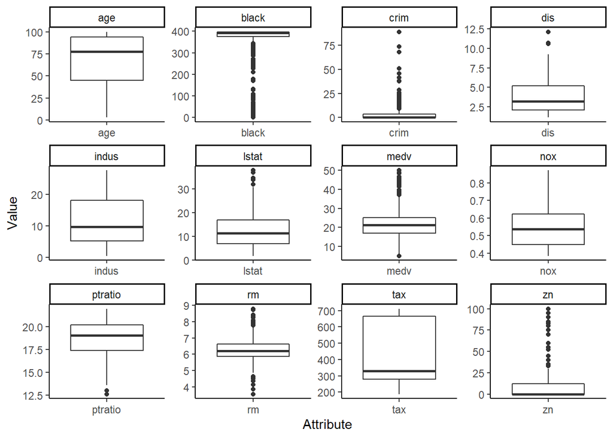

```r
Boston %>%
  pivot_longer(cols = c(1:14), names_to = "Attribute", values_to = "Value") %>%
  filter(!Attribute %in% c("chas","rad")) %>%
  ggplot(aes(x = Attribute, y = Value)) +
  geom_boxplot() +
  facet_wrap("Attribute", scales = "free") +
  theme_classic()
```

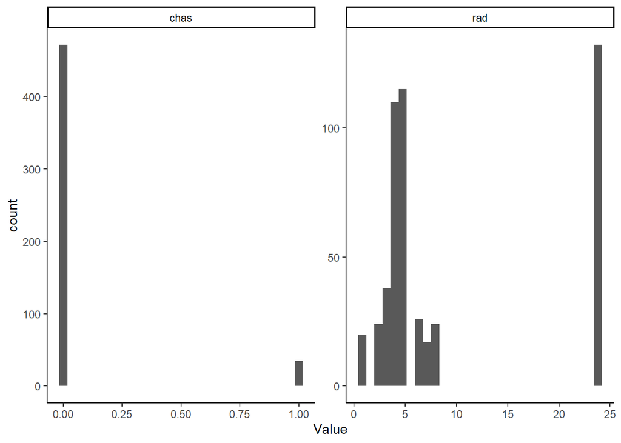

```r
Boston %>%
  pivot_longer(cols = c(1:14), names_to = "Attribute", values_to = "Value") %>%
  filter(Attribute %in% c("chas","rad")) %>%
  ggplot(aes(x = Value)) +
  geom_histogram() +
  facet_wrap("Attribute", scales = "free") +
  theme_classic()
```

We can conclude:

- 93% of towns do not have boundaries to the Charles River.
- Below 10 index of accessibility to radial highways, there seems to be a normal distribution that is disrupted by those with 24 index.
- 3rd quartile of cities only present up to 3.67 crimes per capita.
- Only the 1st quartile is under 375 of black population (see calculation [here](https://stat.ethz.ch/R-manual/R-devel/library/MASS/html/Boston.html)).

Additionally, we can look at the normality of the non-factorial distributions using the qqPlot.

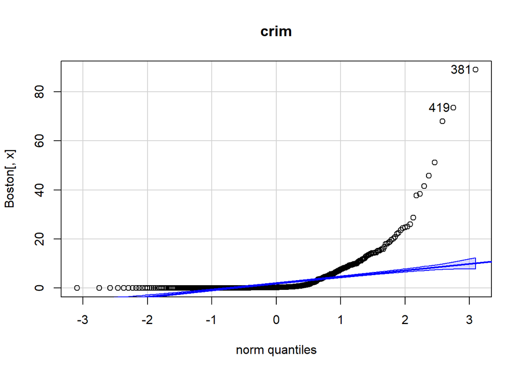

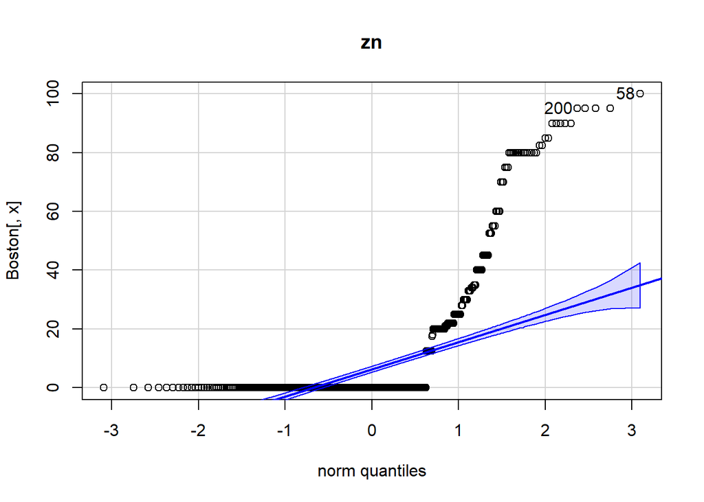

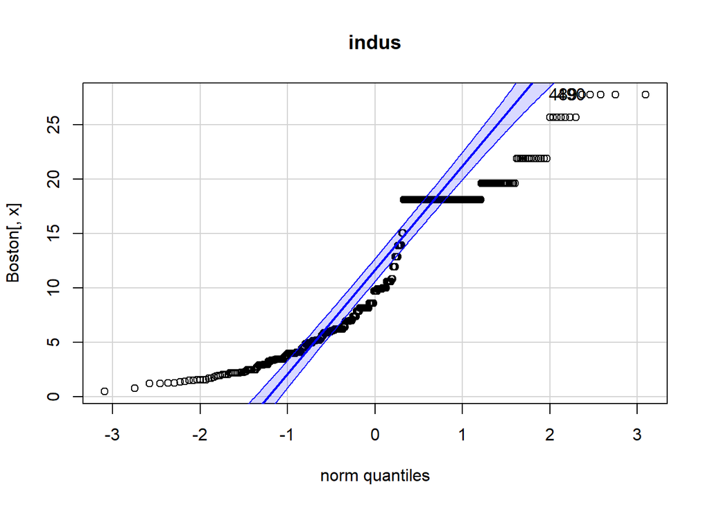

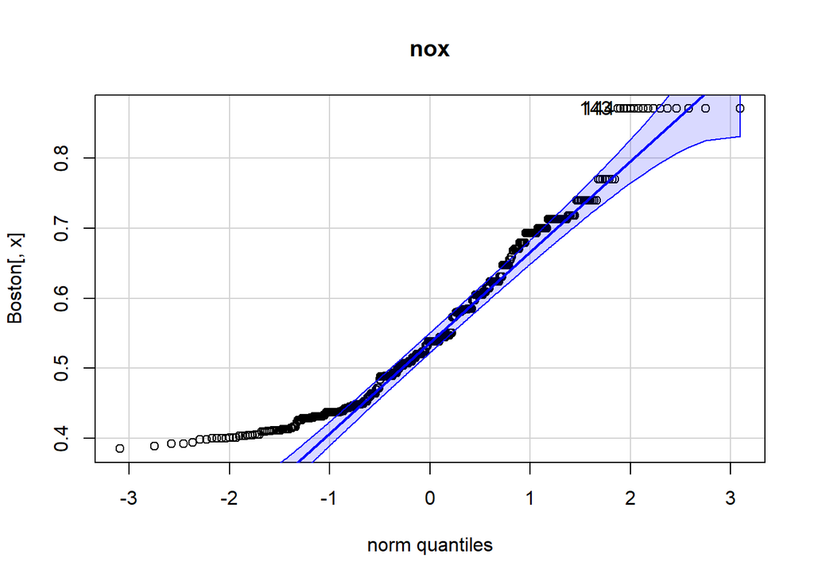

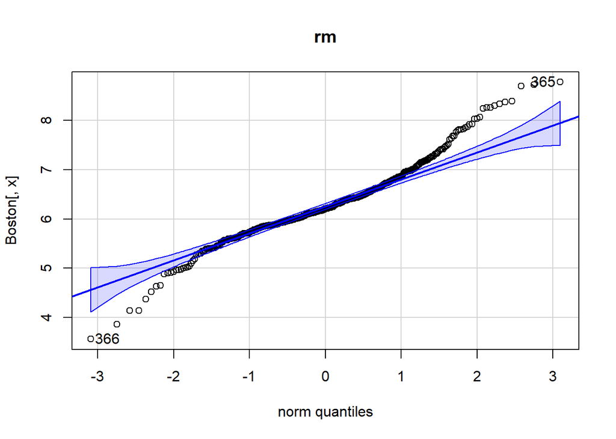

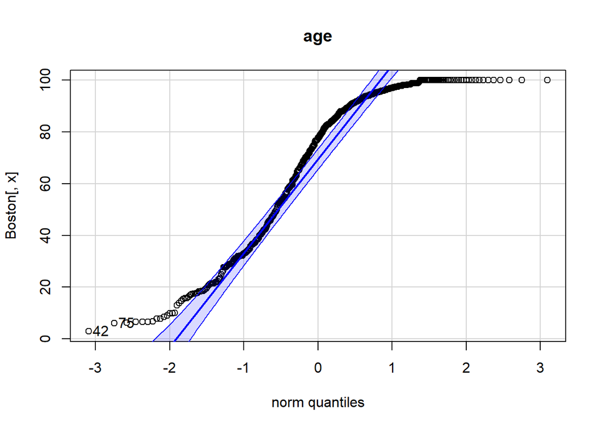

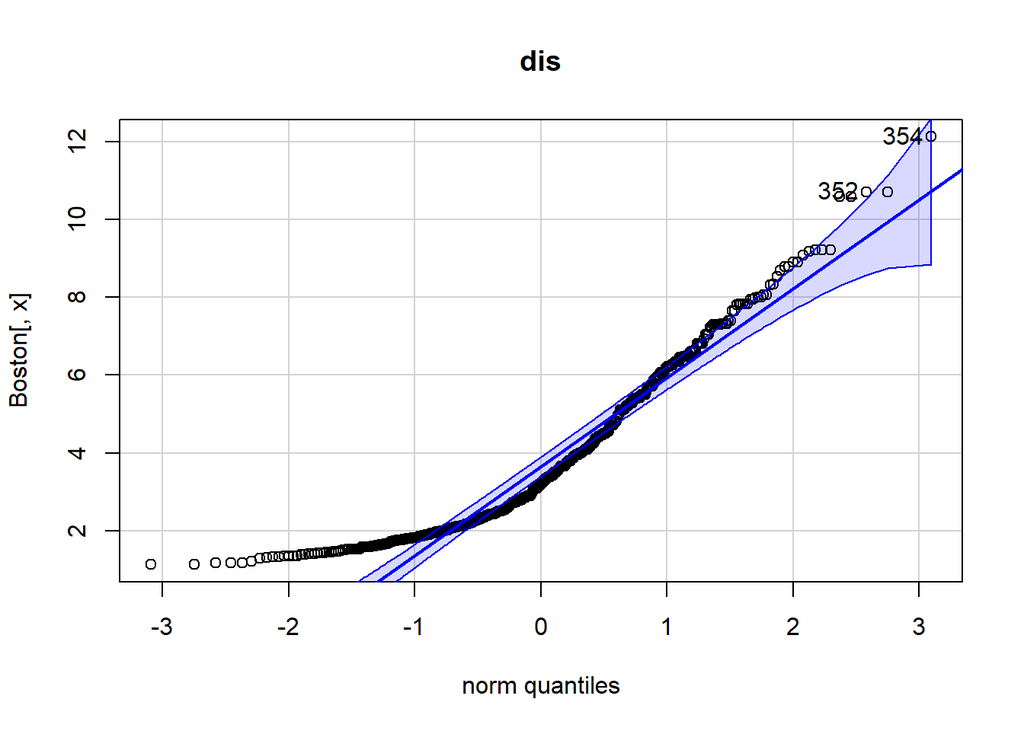

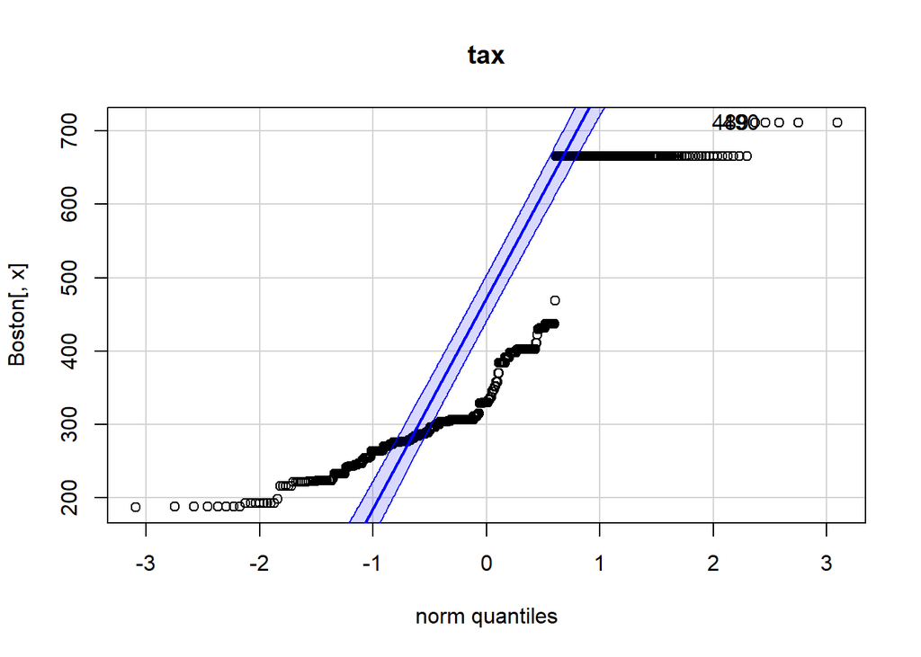

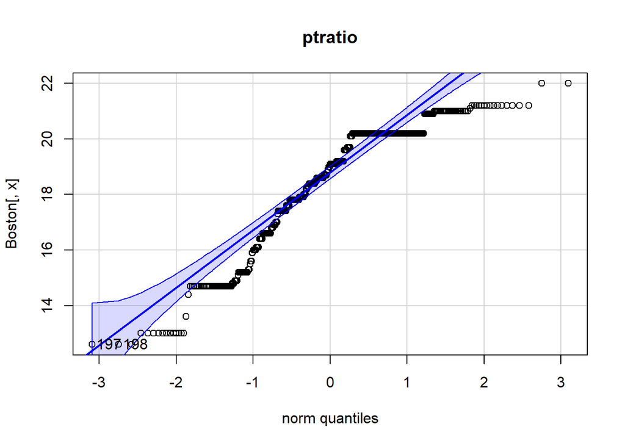

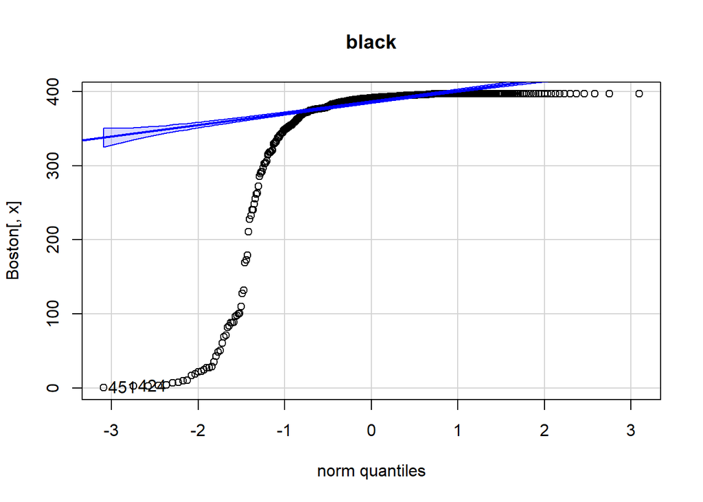

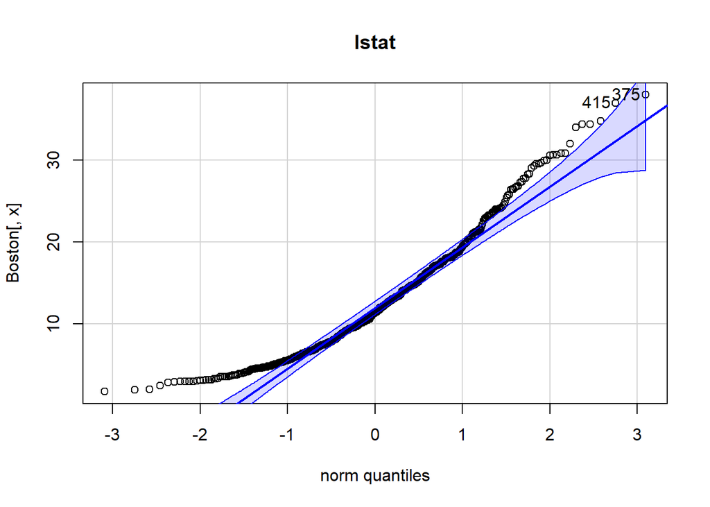

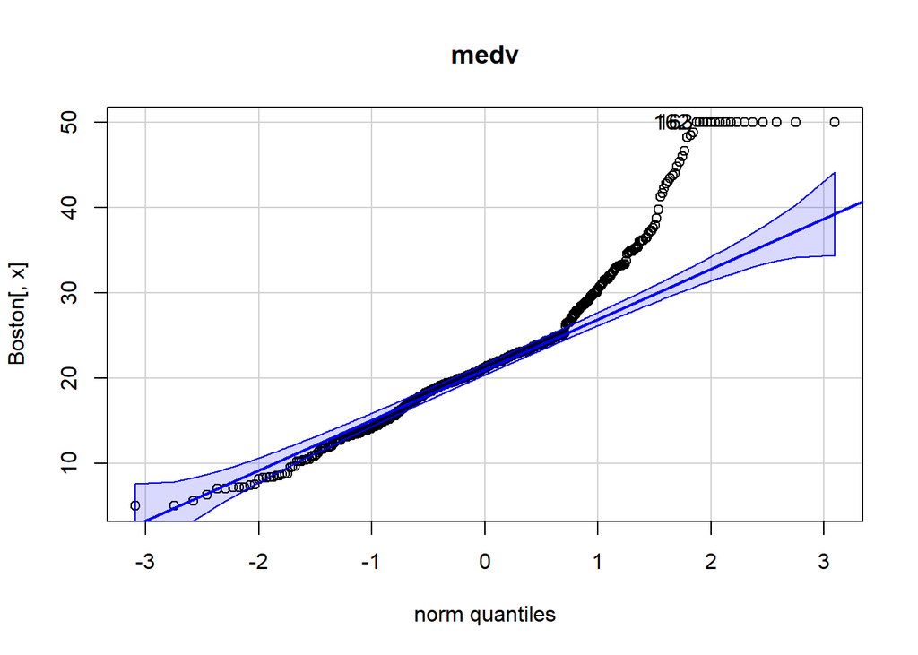

```
##      crim  zn indus nox  rm age dis tax ptratio black lstat medv
## [1,]  381  58   489 143 366  42 354 489     197   451   375  162
## [2,]  419 200   490 144 365  75 352 490     198   424   415  163
```

```r
colnames(Boston)[-c(4,9)] %>% sapply(function(x){
  qqPlot(Boston[,x], main = x)
})
```